# Project 2

Noah Gabriel

11/7/2019

# Intro

Some call it “The Beautiful Game.” Others fondly refer to it as, “America’s Favorite Pastime.” Yet to the communities who play, it’s simply called Magic: the Gathering. Magic is a wonderfully complex game and has evolved greatly since its initial release in 1993. A few core elements, however, have stayed the same. First, the premise of the game has not changed — it is still to defeat your opposing wizard in battle by summoning creatures, attacking them until their “life total” drops from 20 to 0. Second, the “mana system,” or method by which one plays cards, is the same. Mana is magical energy which has five colors: white, blue, black, red, and green, arranged in a pentagram (e.g., black’s “allies” are blue and red). Each color possesses a distinct philosophy which is reflected in the design of the game. White is the color of justice, order, and the law. Blue is the color of knowledge, curiosity, and learning. Black loves power; its greed lets it cheat death. Red is impulsive and aggressive and draws on the element of fire. Green is the color of slow, overpowering growth. As the game has evolved, creatures have steadily grown in power because a design catch-22 called “power creep.” In order to keep new cards relevant, the designers have slowly made creatures stronger; a Wurm in 2019 may exceed its (admittedly vast) 1993 counterpart. This phenomenon may challenge the traditional roles of certain creatures or colors, yet it also showcases the fluid, dynamic, creative landscape of Magic: The Gathering.

The Magic: the Gathering universe is filled with mythical creatures of all types, from diminutive goblins to prodigious Beasts, which embody these colors of mana. Naturally, they differ in size. A Beast may crush a human underhoof, but stands but little chance before the rapacious maw of a Worldspine Wurm.

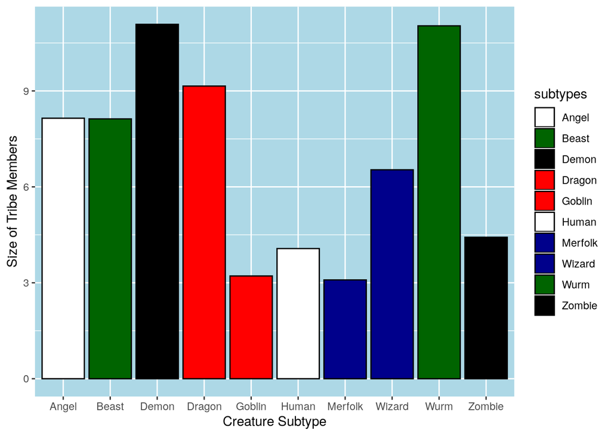

Yet these species do not merely differ in size; they also differ in aggression. Every creature is assigned a “power” and “toughness,” represented by the first and second digits in the bottom right corner of their cards, respectively. Overall, power and toughness tend to be fairly balanced all time. This becomes clear when looking at the card pool of all creatures ever printed.

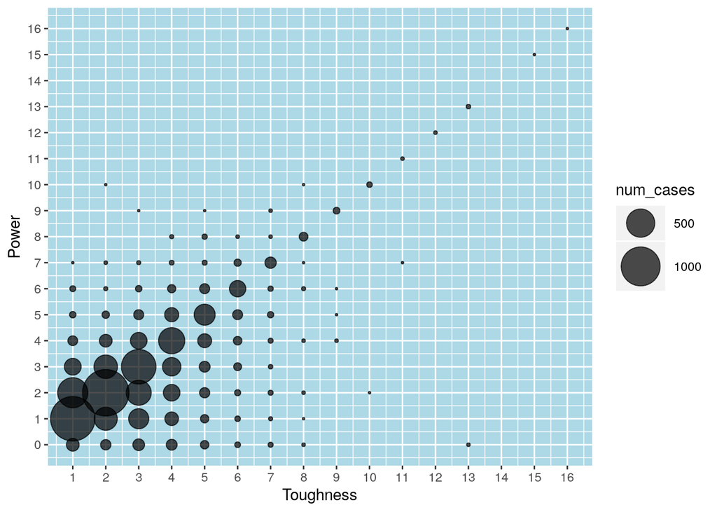

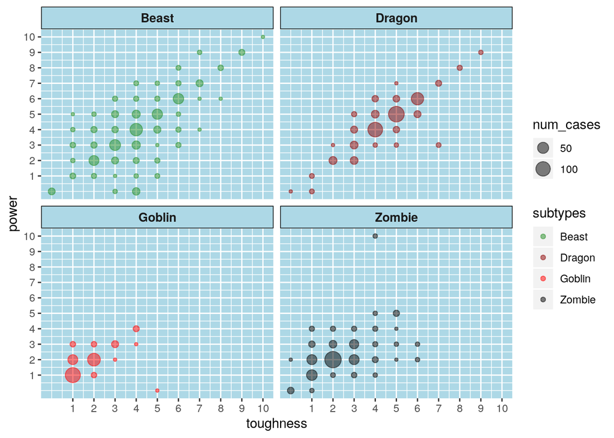

While many creatures fall into specific tribes that commonly occur throughout the MTG multiverse, nearly as many do not. As a result, we must also look beyond tribe and at what is perhaps Magic’s hallmark category breakdown: color. As mentioned above, colors have different assocations and their creatures help embody that notion. While green, the color of primieval beasts and monstrosities, has nearly always boasted more powerful creatures than any of its fellows and thus retained top-dog status, the hierarchy between the other four colors is less clear. What is obvious, however, is the data-backed notion of “power-creep,” or the steady ascent of power levels over time, as can be seen clearly in this graphic, especially in the last five years.

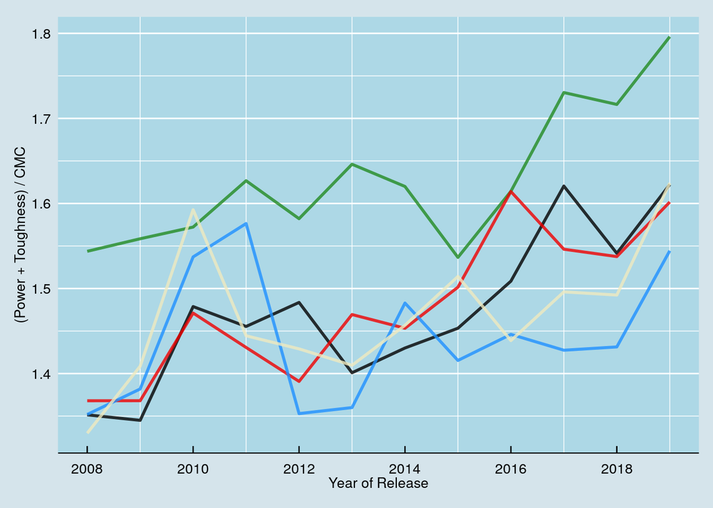

This notion becomes especially clear when examined through the lens of rarity. Wizards of the Coast prints most of its cards in what are called “booster packs,” containing 10 “commons,” 3 “uncommons” and one “rare.” Commons are designed to be simpler and less powerful, serving as a baseline against which other cards are measured.

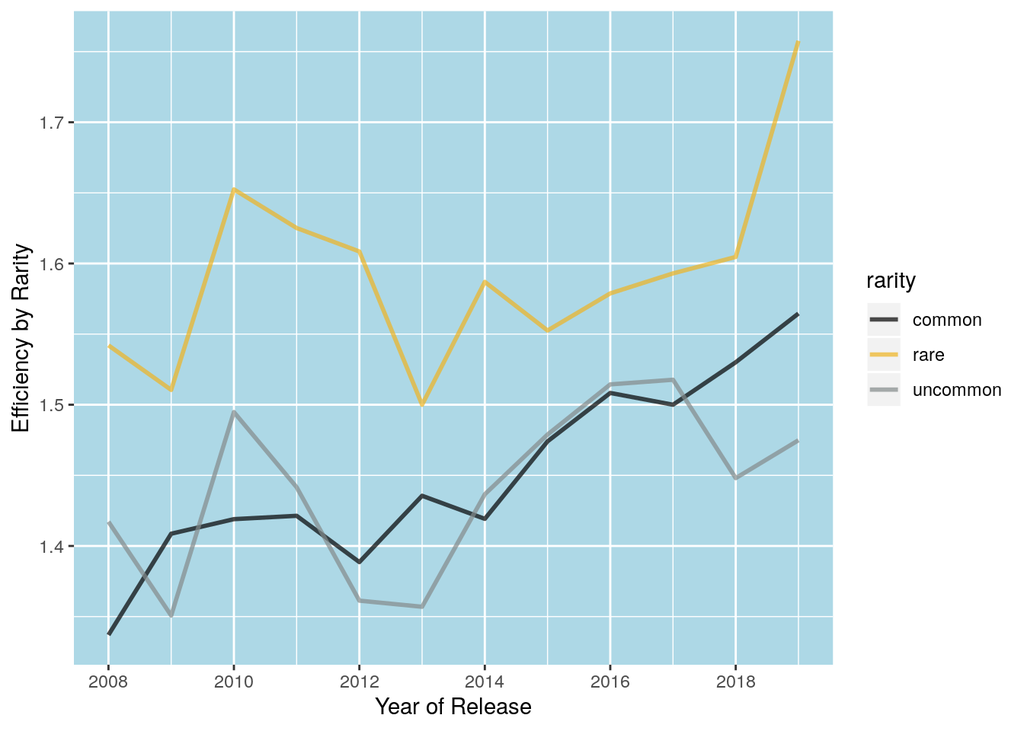

### throwaway scratchwork section

creatures %>% # this shows we need to grepl filter( subtypes == “Wizard” ) %>% arrange( desc(power) )

creatures %>% group_by(subtypes) %>% summarize( num_creatures = sum(n()) ) %>% arrange(desc(num_creatures))

humans_by_occupation <- creatures %>% filter( grepl(“Human”, subtypes) )